# RMSD Pattern Analysis

Nicholas A. Yager

2015-02-25

## Introduction

For the UP-Stat data competition we are tasked to

> discover the most compelling, appealing and practical patterns in the episodes of traffic congestion. The merits will be measured in terms of novelty of the patterns discovered, usability of the recommendations made, and originality of the scientific methods used.

With that in mind, we will approach the problem using a metric called RMSD, the [root-mean-square deviation](https://en.wikipedia.org/wiki/Root-mean-square_deviation). RMSD measures the average deviation of each element of two vectors. This on the whole can provide a single metric for measuring large changes in a day’s traffic in relation to some other set of traffic. In this specific instance, I am comparing each day of the week to the week prior.

## Data Handling

Loading the data is trivial with the exception of the date data. Dates should be converted from a string into a Date object for easy subsetting.

```r
# Read the data ----------------------------------------------------------------
traffic <- read.csv("../../data/UrbanAnalytics2015.csv", sep=" ")

# Remove outliers
traffic[which(traffic$Delay > 5000),1:4] = c(NA,NA,NA,NA)
traffic[which(traffic$Stops > 5000),1:4] = c(NA,NA,NA,NA)

## Parse the datetime as a Date object.
traffic$DateTime <- strptime(traffic$DateTime, "%m/%d/%y %H:%M")

stepsPerDay <- 1440/5
dayList<-c("Sun.","Mon.","Tues.","Wed.","Thurs.","Fri.","Sat.")
```

Let’s define a function that will calculate the RMSD for us. This function must accept two vectors of equal length, and it must also be able to tolerate NA values in the data.

```r
rmsd <- function(vector1, vector2) {
  deviation = (vector1 - vector2)^2
  numNA = length(which(is.na(deviation)))
  return(sqrt(sum(deviation,na.rm=T)/(length(deviation)-numNA)))
}
```

## Templating

First, we need to set some initial templates to compare our data against. To do this, I am making a list of vectors, with each element of the list holding the traffic volume for that day. I will fill the templates with the first week of traffic from our data set.

```r
templates <- list()
for (day in 1:7) {
  startIndex <- (day-1)*stepsPerDay
  endIndex   <- (day)*stepsPerDay -1
  series <- traffic$Delay[startIndex:endIndex]
  templates <- c(templates, list(series))
}
```

## Data agregation

Now, we need to generate vectors to process with our RMSD function. Sadly, the original data contain gaps, outliers, and general nasties. What we will do, is for each day of the week will step week-by-week filling in a matrix of each 5 minute period. After we fill in the matrix for a particular week day, we can calculate the RMSD with respect to the previous week. The function is slower than other heuristic methods, but it does not fall prey to missing data problems that can be experienced other ways.

```r
days <- traffic$DateTime[nrow(traffic)]$yday + 356 - traffic$DateTime[1]$yday
weeks = floor(days/7)
rmsds <- matrix(0, nrow=weeks-1, ncol=7)
for (wday in 0:6) {

  ## For each weekday, compile a matrix of every week's version and compare
  weeklySubset = traffic[which(traffic$DateTime$wday == wday),]
  weeklyMatrix <- matrix(NA,ncol=288, nrow=weeks)
  for (index in 1:nrow(weeklySubset)) {
    dayNumber = 1+  weeklySubset$DateTime[index]$yday + 356 *(weeklySubset$DateTime[index]$year - 113)  - weeklySubset$DateTime[1]$yday
    week = 1 + floor(dayNumber/7)
    minute = 1 + (weeklySubset$DateTime[index]$min + (60*weeklySubset$DateTime[index]$hour))/5
    weeklyMatrix[week, minute] = weeklySubset$Volume[index]
  }
  for (week in 1:(weeks-1)) {
    rmsds[week, wday+1] <- rmsd(weeklyMatrix[week,],weeklyMatrix[week + 1,])
  }
}
```

## Plotting

The `rmsds` matrix returned can be visualized either as a time series, which is a little too messy for my taste

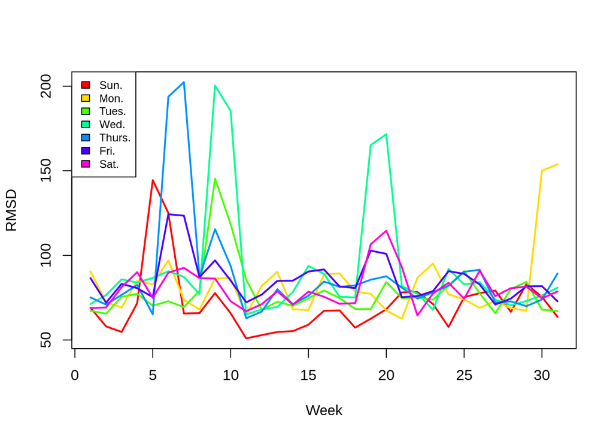

```r
matplot(rmsds,type="l",
        lty=1,lwd=2,col=rainbow(7), ylab="RMSD",xlab="Week")
legend("topleft",legend=dayList,fill=rainbow(7),
       cex=0.75)
```

or as an image.

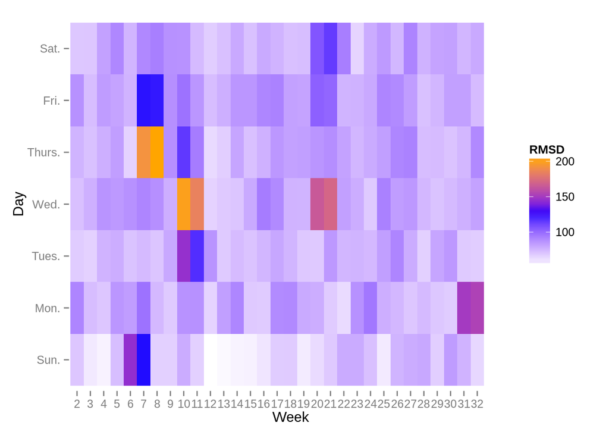

```r
library(ggplot2)
library(reshape2)
ggplot(melt(rmsds), aes(Var1,Var2, fill=value)) +
  scale_fill_gradientn(colours=c("white","blue","orange"),name="RMSD")+
  xlab("Week")+
  ylab("Day")+
  geom_raster() +
  theme( panel.background = element_rect(fill = "transparent", colour = NA),
         panel.grid.minor = element_blank(),
         panel.grid.major = element_blank()) +
  scale_x_discrete(breaks = seq(1, 31, 1), labels = seq(2,32,1))+
  scale_y_discrete(breaks=c("1","2","3","4","5","6","7"), labels=dayList, limits=c(1,2,3,4,5,6,7))
```

It is important to note that one abnormal day will be noticed as a high RMSD as will the following day since it is not no longer as abnormal. It would appear that the Sunday, Thursday, and Friday on the 6th week, the Tuesday, Wednesday, and Thursday on the 10th week, the Wednesday, Friday, and Saturday on the 20th week, and the Monday on the 32nd week.

# Comparisions to the first week

We can also calculate the RMSDs with respect to the first week only.

```r
days <- traffic$DateTime[nrow(traffic)]$yday + 356 - traffic$DateTime[1]$yday
weeks = floor(days/7)
rmsds <- matrix(0, nrow=weeks-1, ncol=7)
for (wday in 0:6) {

  ## For each weekday, compile a matrix of every week's version and compare
  weeklySubset = traffic[which(traffic$DateTime$wday == wday),]
  weeklyMatrix <- matrix(NA,ncol=288, nrow=weeks)
  for (index in 1:nrow(weeklySubset)) {
    dayNumber = 1+  weeklySubset$DateTime[index]$yday + 356 *(weeklySubset$DateTime[index]$year - 113)  - weeklySubset$DateTime[1]$yday
    week = 1 + floor(dayNumber/7)
    minute = 1 + (weeklySubset$DateTime[index]$min + (60*weeklySubset$DateTime[index]$hour))/5

    weeklyMatrix[week, minute] = weeklySubset$Volume[index]
  }
  for (week in 1:(weeks-1)) {
    rmsds[week, wday+1] <- rmsd(weeklyMatrix[1,],weeklyMatrix[week + 1,])
  }
}
```

In doing so, we are able to decrease the RMSD echos seen above while seeing the same general results.

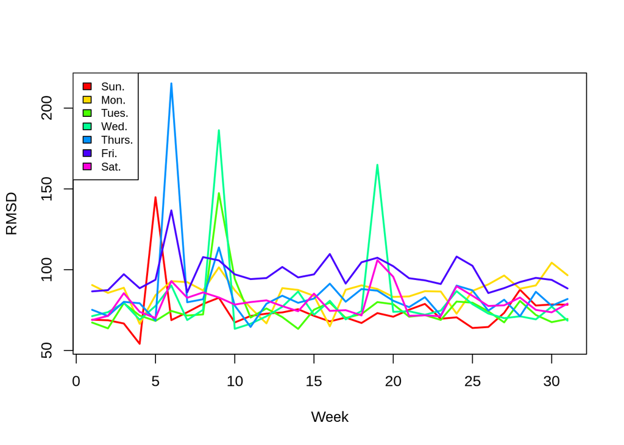

```r
## Simple Plotting -------------------------------------------------------------
matplot(rmsds,type="l",
        lty=1,lwd=2,col=rainbow(7), ylab="RMSD",xlab="Week")
legend("topleft",legend=dayList,fill=rainbow(7),
       cex=0.75)
```

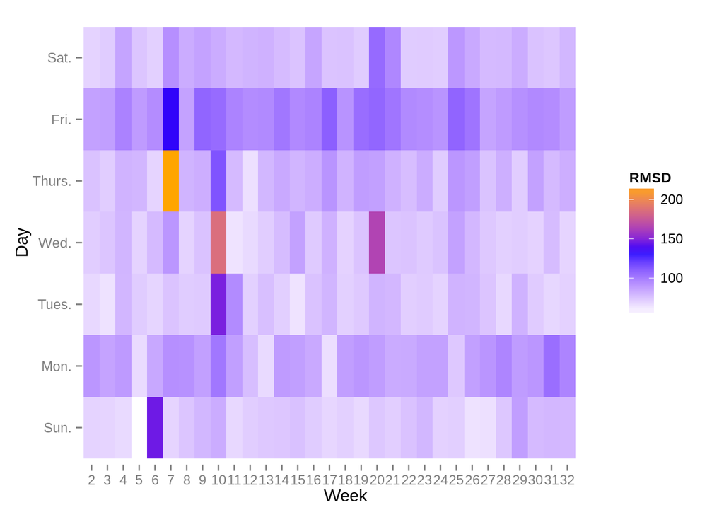

```r
## Plotting --------------------------------------------------------------------
library(ggplot2)
library(reshape2)
ggplot(melt(rmsds), aes(Var1,Var2, fill=value)) +
  scale_fill_gradientn(colours=c("white","blue","orange"), name="RMSD")+
  xlab("Week")+
  ylab("Day")+
  geom_raster() +
  theme( panel.background = element_rect(fill = "transparent", colour = NA),
         panel.grid.minor = element_blank(),
         panel.grid.major = element_blank()) +
  scale_x_discrete(breaks = seq(1, 31, 1), labels = seq(2,32,1))+
  scale_y_discrete(breaks=c("1","2","3","4","5","6","7"), labels=dayList, limits=c(1,2,3,4,5,6,7))
```